# Moderator und Mediation - Formen der Interaktion bei Analyse von Zusammenhängen

admin

2019-12-31

Bei der Analyse von Zusammenhängen tauchen sowohl *Moderation* als auch *Mediation* auf. Es geht um Zusammenhänge zwischen drei Variablen $X$, $Y$ und $M$. Untersucht wird der Effekt einer unabhägigen Variable $X$ (*Prädiktor*, *UV*) auf ein abhängige Variable $Y$ (*AV*). Wir untersuchen dies mit einem Regressionsmodell $Y \sim X$. Dabei wird zusätzlich eine dritte Variable $M$ berücksichtigt, die man entweder der *Moderator* oder *Mediator* nennt.

Ist die abhängige Variable metrisch, so können wir mittels eine linearer Regression vorgehen, ist die AB dagegen dichotom, so nutzen wir eine logistische Regression.

## Moderation

Bei einer *Moderation* wirkt die dritte Variable $M$ (*Moderator*) auf die Beziehung zwischen $X$ und $Y$.

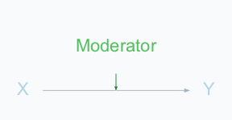

Der Einfluss von $M$ ändert also den Effekt von $X$ auf $Y$. Der Zusammenhang zwischen $Y$ und $X$ ist also je nach $M$ unterschiedlich.

Statistisch gesehen liegt eine *Interaktion* zwischen $M$ und $X$ vor.

### Wie untersucht man einen Zusammenhang auf eine Moderation?

Dazu stellen wir ein Regressionsmodell mit den drei Faktoren $X$, $M$ und der Interaktion zwischen $X$ und $M$ auf.

```r
lm(Y ~ X * M, data=daten)
```

Oder alternativ:

```r
lm(Y ~ X + M + M:X, data=daten)
```

Diese drei Faktoren wirken auf $Y$. Ist in diesem Modell die Interaktion $M:X$ *signifikant*, so liegt eine (signifikante) *Moderation* vor.

## Mediation

Bei der *Mediation* steht die Variable $M$ (der *Mediator*) sowohl zu $X$ als auch zu $Y$ in Beziehung. Der direkte Effekt zwischen $X$ und $Y$ wird durch den indirekten Effekt über $M$ erklärt, also durch $X \to M \to Y$.

### Wie untersucht man auf eine Mediation?

In diesem Fall stellen wir mehrere Regressionsmodelle auf. Eine (signifikante) Mediation liegt dann vor, wenn die folgenden Bedinungen erfüllt sind:

```r
erstesModell <- lm(Y ~ X, data=daten)
zweitesModell <- lm(M ~ X, data=daten)
drittesModell <- lm(Y ~ X + M, data=daten)
```

1. Im ersten Modell ($X \to Y$) ist der Regressionskoeffizient von $X$ signifikant.
2. Im zweiten Modell ($X \to M$) ist der Regressionskoeffizient von $X$ signifikant.
3. Im dritten Modell ($X,M \to Y$) ist der Regressionskoeffizient von $M$ signifikant und
4. der Regressionskoeffizient von $X$ im dritten Modell kleiner als im ersten Modell.